# Homework 2

Forecasting: Principles and Practice - The Forecasters Toolbox

Paul Perez

2/21/2021

# Exercise 3.7 - 1

For the following series, find an appropriate Box-Cox transformation in order to stabilise the variance.

- `usnetelec`
- `usgdp`
- `mcopper`
- `enplanements`

## usnetelec

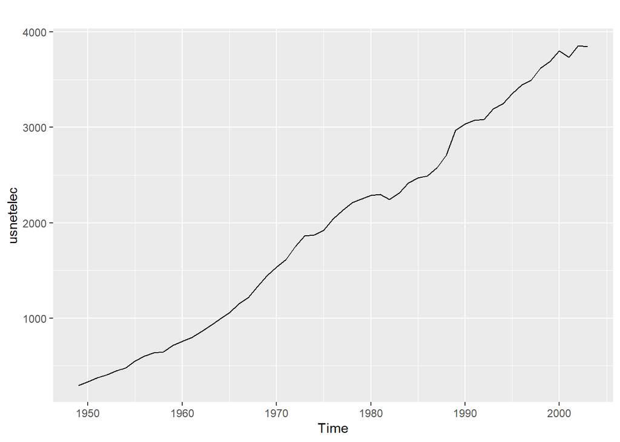

```r
autoplot(usnetelec)
```

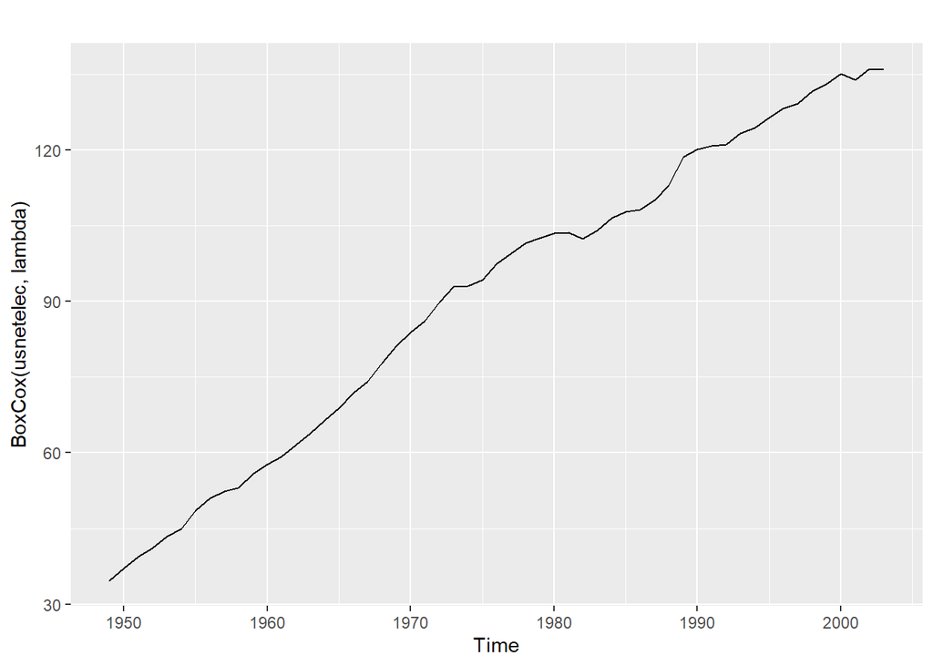

```r
lambda <- BoxCox.lambda(usnetelec)
autoplot(BoxCox(usnetelec, lambda))
```

The lambda for the `usnetelec` Box-Cox is 0.5167714.

## usgdp

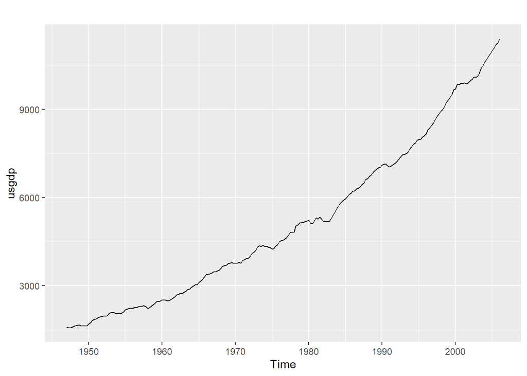

```r
autoplot(usgdp)
```

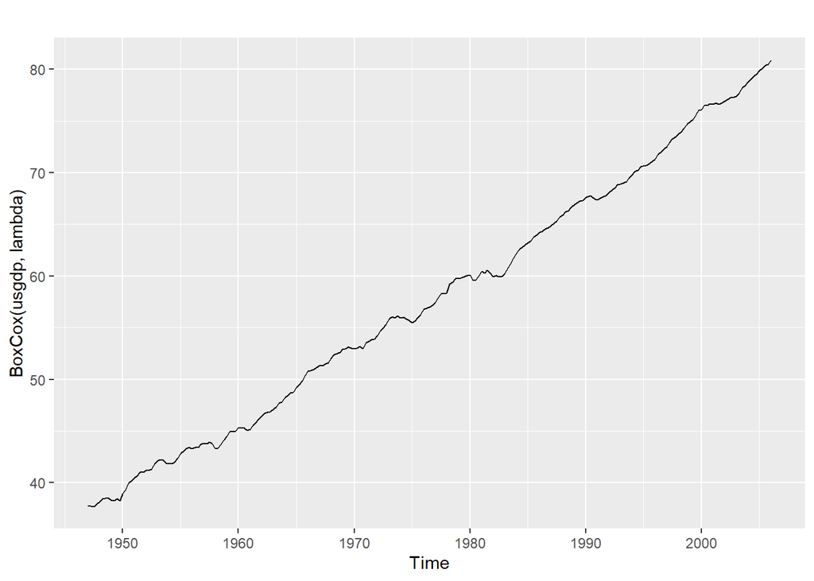

```r
lambda <- BoxCox.lambda(usgdp)
autoplot(BoxCox(usgdp, lambda))
```

The lambda for the `usgdp` Box-Cox is 0.366352.

## mcopper

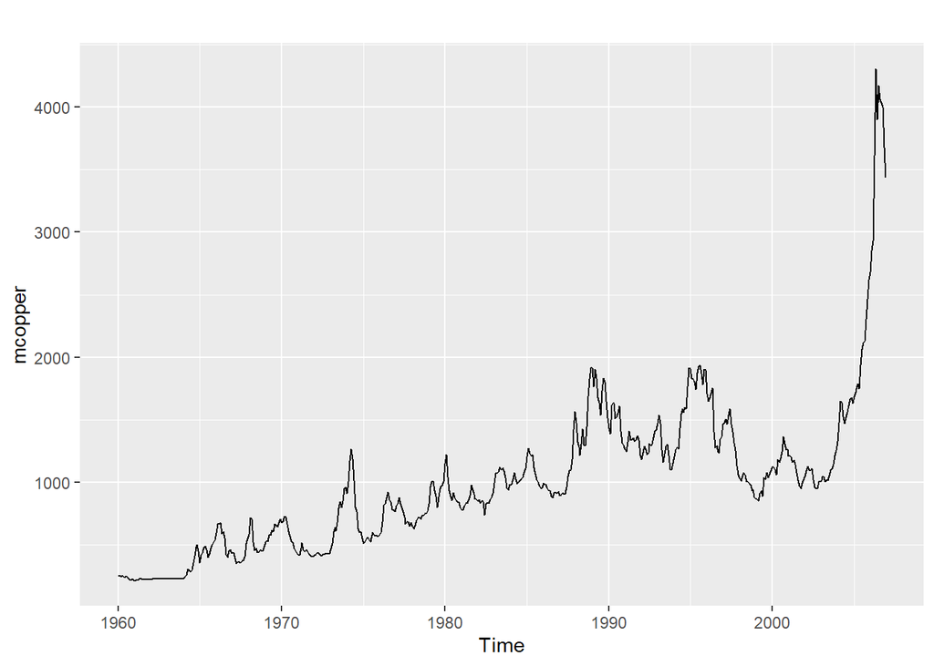

```r
autoplot(mcopper)
```

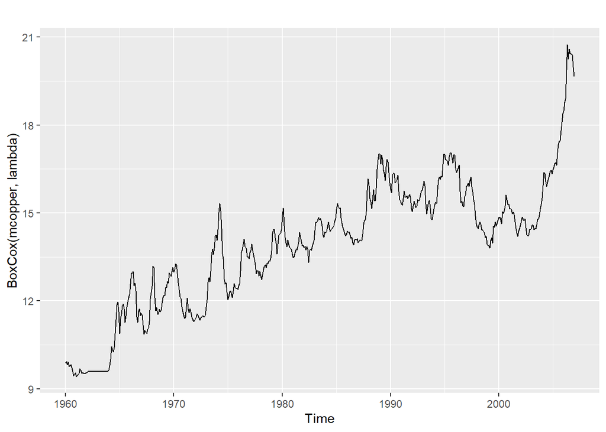

```r
lambda <- BoxCox.lambda(mcopper)
autoplot(BoxCox(mcopper, lambda))
```

The lambda for the `mcopper` Box-Cox is 0.1919047.

## enplanements

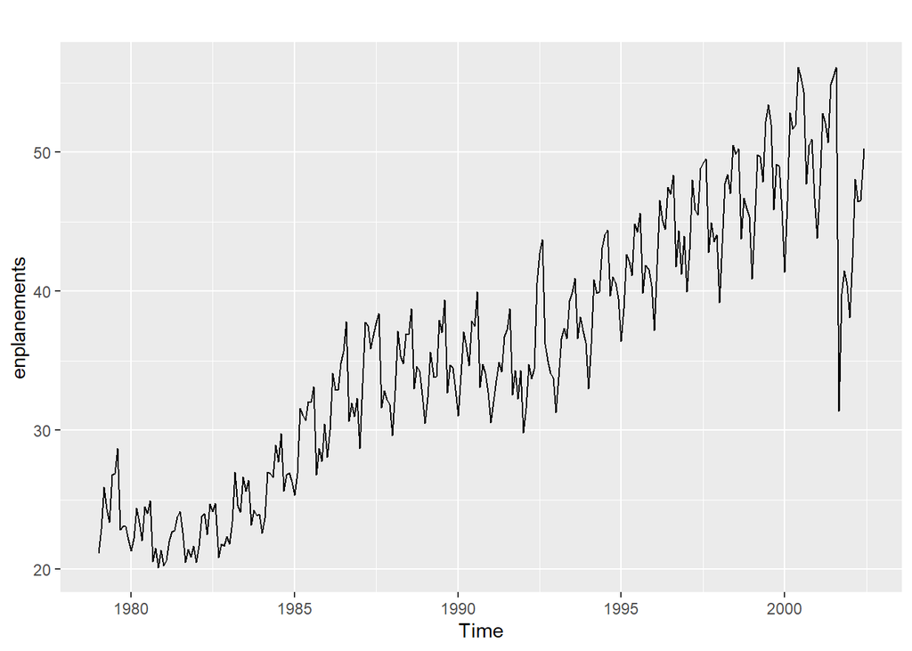

```r
autoplot(enplanements)
```

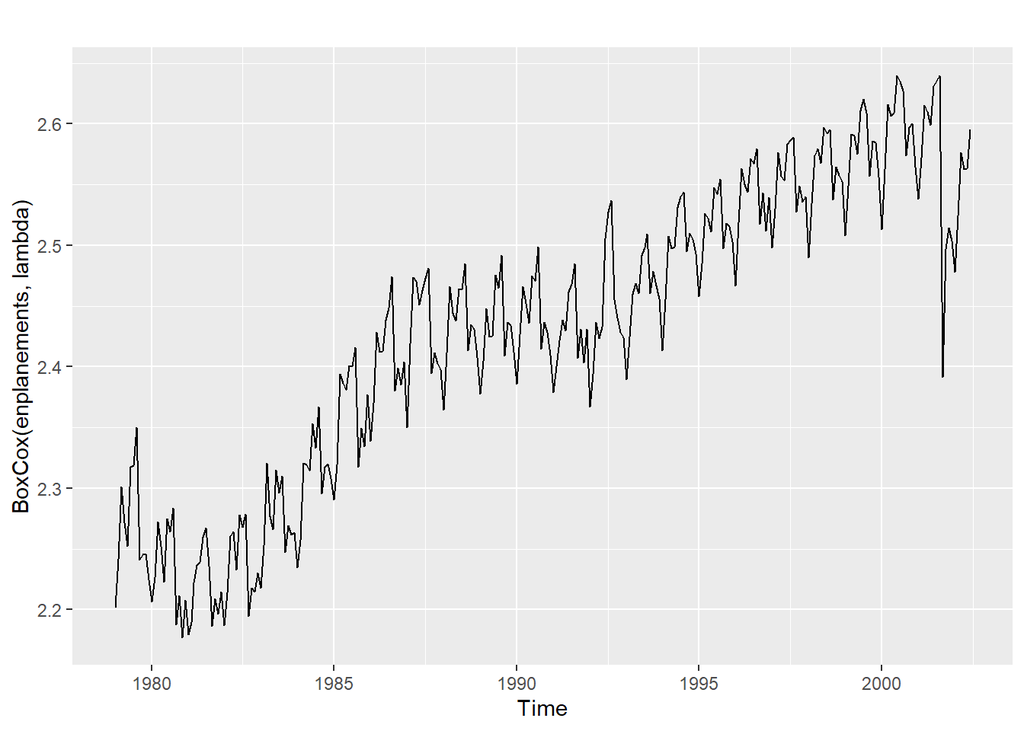

```r
lambda <- BoxCox.lambda(enplanements)
autoplot(BoxCox(enplanements, lambda))
```

The lambda for the `enplanements` Box-Cox is -0.2269461.

# Exercise 3.7 - 2

Why is a Box-Cox transformation unhelpful for the `cangas` data?

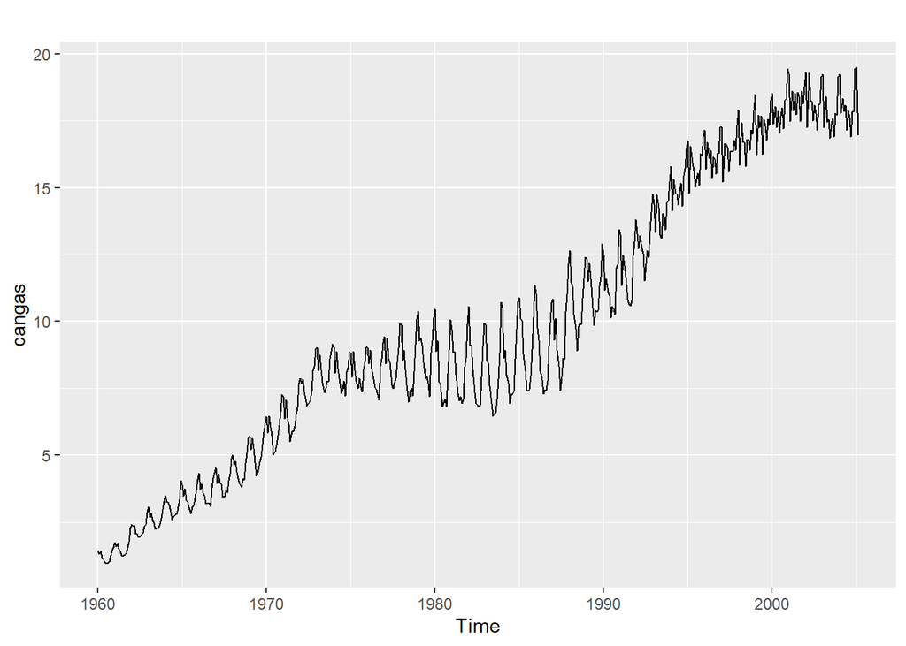

```r
autoplot(cangas)
```

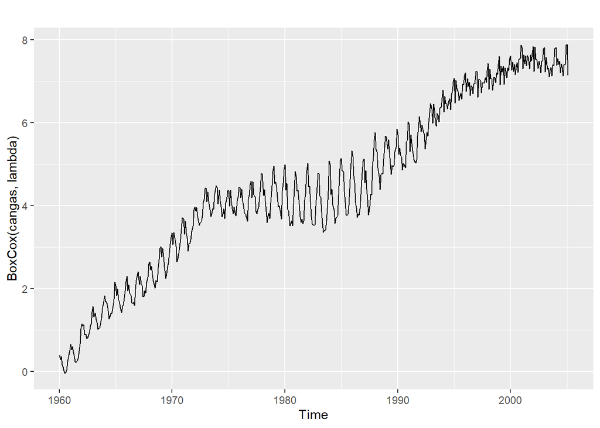

```r
lambda <- BoxCox.lambda(cangas)
autoplot(BoxCox(cangas, lambda))
```

Looking at both plots, the original and Box-Cox transformation, there does not appear to be much of a change. Specifically looking at the window of the mid 1970’s through to 1990, the variance seems to increase on both plots. We’ll need to use a different transformation to handle this dataset.

# Exercise 3.7 - 3

What Box-Cox transformation would you select for your retail data (From Exercise 3 in Section 2.10)?

```r
retaildata <- readxl::read_excel("retail.xlsx", skip=1)

myts <- ts(retaildata[,"A3349414R"],
  frequency=12, start=c(1982,4))
```

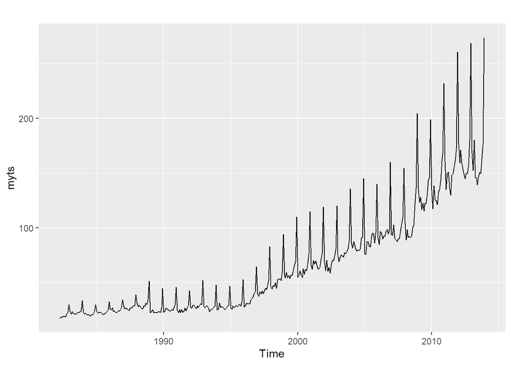

```r
autoplot(myts)
```

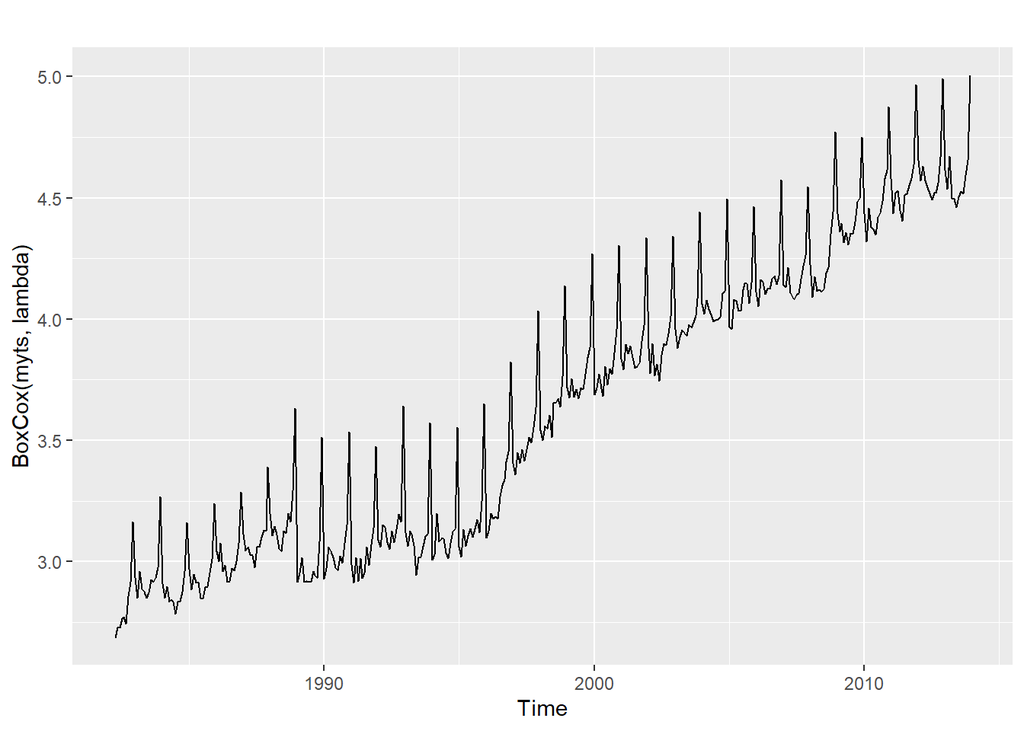

```r
lambda <- BoxCox.lambda(myts)
autoplot(BoxCox(myts, lambda))
```

Looking into my retail data from exercise 3 in section 2.10, the `BoxCox.lamnda()` function provides us with an ideal lambda of `-0.04159144`. Being that this is negative, and our `BoxCox()` function allows for negative values, we’re going to use a Power Transformation using a sign function in the formula. Please see below.

$$w_t =
\begin{cases}
\log(y_t) & \text{if $\lambda=0$}; \\
\text{sign}(y_t)(|y_t|^\lambda-1)/\lambda & \text{otherwise}.
\end{cases}$$

# Exercise 3.7 - 8

For your retail time series (from Exercise 3 in Section 2.10):

## a. Split the data into two parts using

```r
myts.train <- window(myts, end=c(2010,12))
myts.test <- window(myts, start=2011)
```

## b. Check that your data have been split appropriately by producing the following plot.

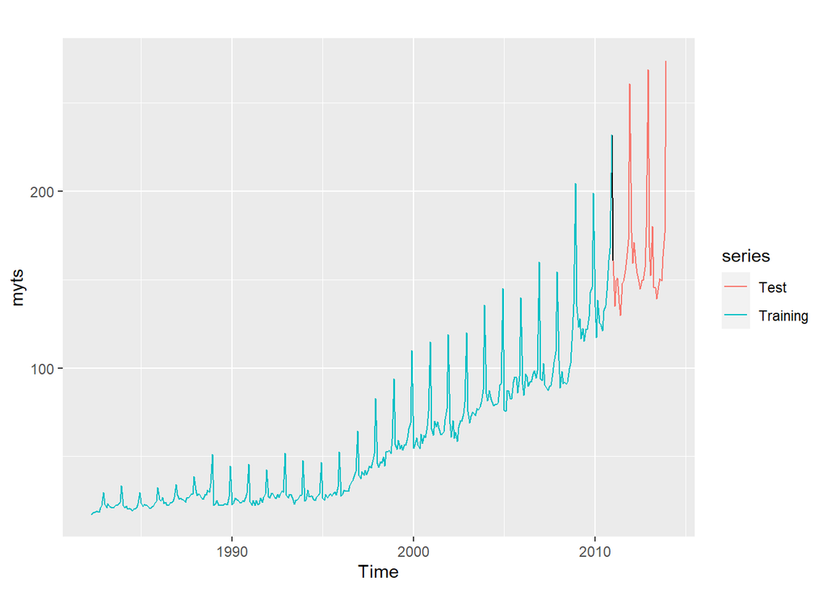

```r
autoplot(myts) +
  autolayer(myts.train, series="Training") +
  autolayer(myts.test, series="Test")
```

## c. Calculate forecasts using `snaive` applied to `myts.train`.

```r
fc <- snaive(myts.train)
```

## d. Compare the accuracy of your forecasts against the actual values stored in `myts.test`.

```r
accuracy(fc,myts.test)
```

```
##                     ME      RMSE       MAE      MPE      MAPE     MASE
## Training set  4.455255  8.699864  5.818619  6.15400  9.948117 1.000000
## Test set     19.170833 22.956217 19.520833 11.59039 11.813322 3.354891
##                   ACF1 Theil's U
## Training set 0.7261600        NA
## Test set     0.5801161 0.7479721
```

## e. Check the residuals.

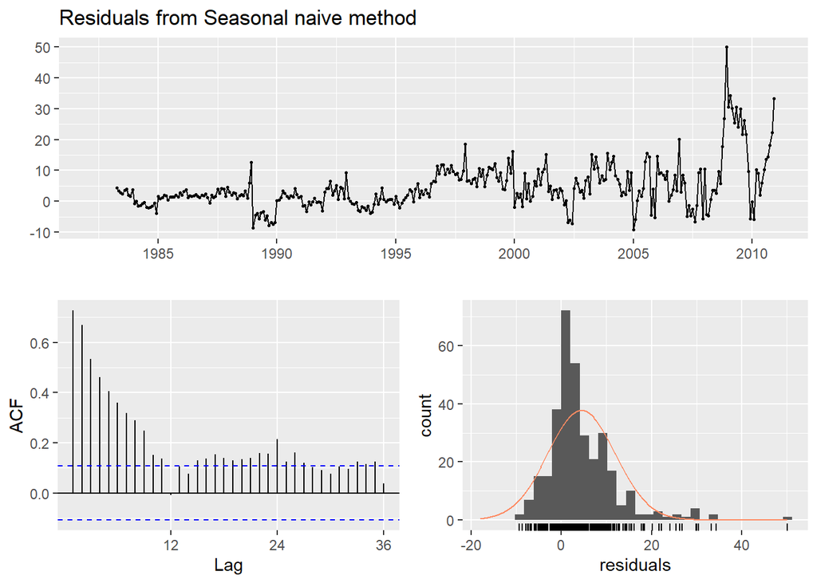

```
##
##  Ljung-Box test
##
## data:  Residuals from Seasonal naive method
## Q* = 783.91, df = 24, p-value < 2.2e-16
##
## Model df: 0.   Total lags used: 24
```

```r
checkresiduals(fc)
```

Do the residuals appear to be uncorrelated and normally distributed?

While there is a slight skew to the right on the residuals distribution plot, there seems to be strong significant of correlation in the lags of the ACF plot.

## f. How sensitive are the accuracy measures to the training/test split?

```r
myts.train <- window(myts, end=c(2010,12))
myts.test <- window(myts, start=2011)

myts.train2 <- window(myts, end=c(2006,12))
myts.test2 <- window(myts, start=2007)

myts.train3 <- window(myts, end=c(2008,12))
myts.test3 <- window(myts, start=2009)

fc <- snaive(myts.train)
fc2 <- snaive(myts.train2)
fc3 <- snaive(myts.train3)

accuracy(fc, myts.test)
```

```
##                     ME      RMSE       MAE      MPE      MAPE     MASE
## Training set  4.455255  8.699864  5.818619  6.15400  9.948117 1.000000
## Test set     19.170833 22.956217 19.520833 11.59039 11.813322 3.354891
##                   ACF1 Theil's U
## Training set 0.7261600        NA
## Test set     0.5801161 0.7479721
```

```r
accuracy(fc2, myts.test2)
```

```
##                    ME      RMSE      MAE      MPE     MAPE     MASE      ACF1
## Training set 3.298947  6.037997 4.557193 5.784881 9.901433 1.000000 0.6028602
## Test set     5.904167 14.129800 8.604167 4.290980 7.069659 1.888041 0.5801372
##              Theil's U
## Training set        NA
## Test set     0.7066347
```

```r
accuracy(fc3, myts.test3)
```

```
##                     ME      RMSE       MAE       MPE      MAPE     MASE
## Training set  3.468608  6.893273  4.862783  5.641569  9.679051 1.000000
## Test set     28.770833 30.430926 29.237500 21.592543 21.827284 6.012503
##                   ACF1 Theil's U
## Training set 0.5475324        NA
## Test set     0.4978109  1.549617
```

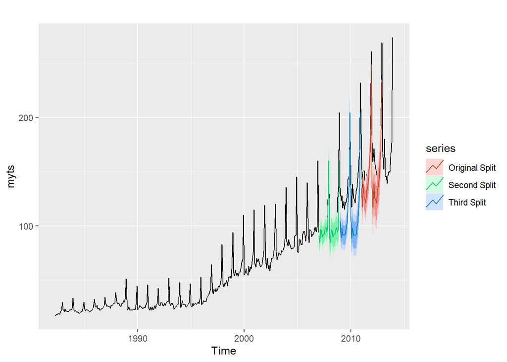

```r
autoplot(myts) +
  autolayer(fc, series = "Original Split") +
  autolayer(fc2, series = "Second Split") +
  autolayer(fc3, series = "Third Split")
```

The second split created looks to be the best predicition in this example. I think given these various timeframes to predict against and the varied results, we can say that this accuracy mesaures between the training and test split are sensitive.